# Predicting type of exercise

## Practical Machine Learning course project

Katrin Wolff  
phys

## Some preprocessing of data

**Goal**: The aim of this course project is to predict the type of exercise performed by test from the measurements of fitness devices.

Looking at the column names of the data it is obvious that some columns report "non-features" like usernames or timestamps and others give summary properties like average pitch of forearm or similar. In a first preprocessing step I clean the data of those columns as they are either not available for single test cases or should not contribute to the prediction (unless user Jeremy always performs the same exercise but that would defeat the purpose of predicting from device measurements).

```r
nonfeaturesindices <- c(1:7, grep("kurtosis", colnames(data)), grep("skewness", colnames(data)),
                        grep("max", colnames(data)), grep("min", colnames(data)),
                        grep("amplitude", colnames(data)), grep("var", colnames(data)),
                        grep("stddev", colnames(data)), grep("avg", colnames(data))
                        )
data <- data[-nonfeaturesindices]
```

## Splitting into test and training set

The cleaned data are then split into 60% training and 40% test set. All further feature selection and cross validation will be done on the training set and the test set will only be used for final validation and error estimation.

```r
set.seed(1234)
inTrain <- createDataPartition(data$classe, p = 0.6, list = FALSE)
training <- data[inTrain,]
testing <- data[-inTrain,]
```

## First overview of features

There are still 52 possible prediction criteria left but many of them are correlated. This makes it very hard to choose good features by looking at plots. Here is a paired feature plot for one measure on the belt, arm, dumbbell and forearm each.

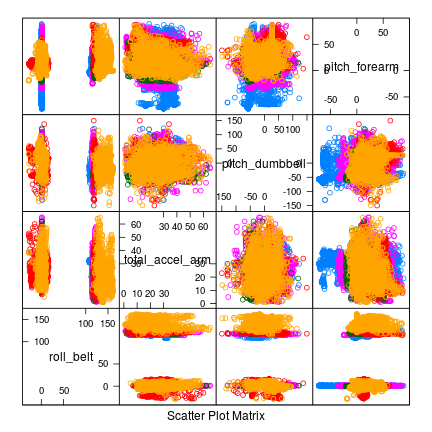

The objective in feature selection would be to split the differently coloured clouds (different exercise classes A-E) as well as possible using only a few features.

I will not attempt to do this by hand but rely on automatic feature selection of the random forest method in caret.

## Choosing a method

My first attempt was to use "traditional" CART decision tree building as trees can deal with non-linear predictions yet are simple to interpret. However, the results were very poor, even when changing tunelengths and cross validation numbers, accuracy was only about 50% for exercise type (classe) and some classes were not predicted at all.

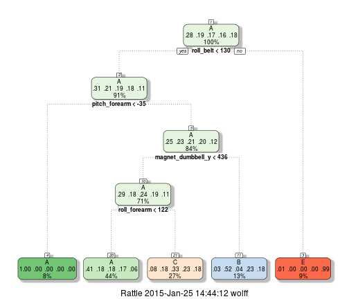

I therefore decided to "upgrade" to random forest prediction where averages over multiple trees are computed using randomly selected subsamples with randomly selected feature variables.

The main advantage will be to include more of the features without making individual trees deeper.

## Building the model

```r
cvCtrl <- trainControl(method = "cv", number = 3)
fitMod <- train(classe ~ ., data = training, method = "rf", trControl = cvCtrl)
```

In order to cross-validate the models within the training set, a control function is passed to caret's training function specifying a 3-fold partition of the training data. Within each partition the random forest method operates by bootstrapping subsamples and feature variables to build the default number of trees.

This is the main part of the prediction and on my PC takes about 5 minutes.

## In-sample and out-of-sample confusion matrices

A very intuitive way to assess the prediction error is by confusion matrices where each entry shows how many cases of one type were predicted as each possible type.

```r
predictontraining <- predict(fitMod$finalModel, newdata = training, type = "class")
cm <- confusionMatrix(predictontraining, training$classe)$table
round(cm / colSums(cm), 3)
```

In-sample: Using the training set

```
##           Reference
## Prediction A B C D E
##          A 1 0 0 0 0
##          B 0 1 0 0 0
##          C 0 0 1 0 0
##          D 0 0 0 1 0
##          E 0 0 0 0 1
```

Out-of-sample: Using the testing set

```
##           Reference
## Prediction     A     B     C     D     E
##          A 1.000 0.009 0.000 0.000 0.000
##          B 0.000 0.984 0.008 0.001 0.002
##          C 0.001 0.004 0.985 0.014 0.001
##          D 0.000 0.000 0.007 0.983 0.003
##          E 0.000 0.000 0.000 0.001 0.994
```

## In-sample and out-of-sample accuracy

The overall accuracy gives the fraction of correctly identified outcomes and is one of the most widely used performance measures.

In order to predict model performace the out-of-sample accuracy is most important as it may indicate instances of over-fitting. It is obtained from the test set, which has been withheld from model-building exactly for this reason.

Here, accuracy is also very high for the testing set.

In-sample: Using the training set

```
## Accuracy
##        1
```

Out-of-sample: Using the testing set

```
##  Accuracy
## 0.9901861
```

## Missed predictions

Finally, here is a plot visualizing false predictions. While the misses appear somewhat clustered in the space spanned by two arbitrarily selected features, they are also within regions populated by correct predictions so it is not obvious if (much less how) they could have been assigned correctly by better methods.

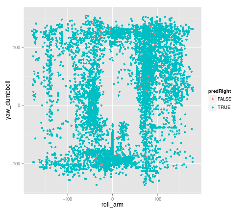

The axes are two arbitrarily selected features from all 52 variables but the overall picture is similar for other pairs of features.